# part 2 Final DM

2025-04-01

Note: Some packages display warnings about being built under R version 4.4.3, while my current environment uses an earlier version. These warnings are non-critical and do not affect the execution or output of the code. All functionality has been tested and works as expected.

#Part II: Supervised Learning – Classification (Predicting Gender from Smartphone Usage) This section presents a classification model to predict gender based on smartphone usage, personality traits (HEXACO), and socioeconomic status. The objective is to explore how these factors relate to gender differences in digital behavior, with implications for targeted marketing and product strategy.

#EDA:

```r
library(tidyverse)
library(caret)
library(randomForest)
library(ROCR)
library(GGally)
df2 <- read.csv("dataset_2.csv")

glimpse(df2)
```

```
## Rows: 532
## Columns: 12
## $ Smartphone               <chr> "iPhone", "iPhone", "iPhone", "iPhone", "iPho…
## $ Gender                   <chr> "male", "male", "male", "male", "male", "male…
## $ Age                      <chr> "24", "39", "31", "22", "43", "20", "20", "20…
## $ Honesty.Humility         <dbl> 3.3, 3.5, 3.9, 3.0, 3.6, 2.7, 4.3, 3.5, NA, 2…
## $ Emotionality             <chr> "2.4", "2.6", "2.4", "3", "1.8", "3", "3.1", …
## $ Extraversion             <dbl> 3.3, 4.3, 2.7, 2.8, 2.0, 3.7, 2.1, 2.0, 3.6, …
## $ Agreeableness            <chr> "3.4", "4", "4.1", "2.4", "2.6", "2.8", "3.5"…
## $ Conscientiousness        <dbl> 3.1, 3.2, 3.7, 2.2, 3.9, 3.0, 3.9, 3.1, 3.4, …
## $ Openness                 <chr> "3.3", "4.5", "4.9", "2.5", "3.1", "3.8", "3.…
## $ Phone.as.status.object   <dbl> 1.8, 2.0, 1.3, 2.7, 1.2, 1.7, 1.0, 2.7, 2.8, …
## $ Social.Economic.Status   <int> 6, 13, 2, 4, 3, 6, 6, 6, 7, 7, 5, 16, 3, 5, 8…
## $ Time.owned.current.phone <int> 18, 2, 22, 2, 4, 4, 1, 6, 16, 14, 39, 36, 16,…
```

```r
colSums(is.na(df2))
```

```
##               Smartphone                   Gender                      Age
##                        0                        0                        0
##         Honesty.Humility             Emotionality             Extraversion
##                        5                        0                        1
##            Agreeableness        Conscientiousness                 Openness
##                        0                        1                        0
##   Phone.as.status.object   Social.Economic.Status Time.owned.current.phone
##                        4                        4                        8
```

Initial issues in the data included: • Several numeric fields (e.g., Age, Emotionality) were read as character • Presence of invalid values (e.g., “s”, “t”) and outliers (e.g., Age = 223) • Missing values in key fields

```r
to_numeric <- c("Age", "Emotionality", "Agreeableness", "Openness")

# Coerce to numeric (non-numeric values become NA)
df2[to_numeric] <- lapply(df2[to_numeric], function(x) as.numeric(as.character(x)))
# Remove rows with invalid or extreme ages
df2 <- df2 %>%
  filter(!is.na(Age), Age >= 15, Age <= 100)

# Remove rows with any NA values
df2_clean <- df2 %>%
  mutate(
    Gender = factor(Gender),
    Smartphone = factor(Smartphone)
  ) %>%
  drop_na()

str(df2_clean)
```

```
## 'data.frame':    489 obs. of  12 variables:
##  $ Smartphone              : Factor w/ 3 levels "Android","BlackBerry",..: 3 3 3 3 3 3 3 3 3 3 ...
##  $ Gender                  : Factor w/ 3 levels "female","male",..: 2 2 2 2 2 2 2 2 2 2 ...
##  $ Age                     : num  24 39 31 22 43 20 20 20 19 21 ...
##  $ Honesty.Humility        : num  3.3 3.5 3.9 3 3.6 2.7 4.3 3.5 2 3 ...
##  $ Emotionality            : num  2.4 2.6 2.4 3 1.8 3 3.1 4.3 1.6 3.3 ...
##  $ Extraversion            : num  3.3 4.3 2.7 2.8 2 3.7 2.1 2 3.5 3.2 ...
##  $ Agreeableness           : num  3.4 4 4.1 2.4 2.6 2.8 3.5 3.4 1.4 3.5 ...
##  $ Conscientiousness       : num  3.1 3.2 3.7 2.2 3.9 3 3.9 3.1 2.8 3.7 ...
##  $ Openness                : num  3.3 4.5 4.9 2.5 3.1 3.8 3.3 3.1 3.2 3.3 ...
##  $ Phone.as.status.object  : num  1.8 2 1.3 2.7 1.2 1.7 1 2.7 2.7 2.5 ...
##  $ Social.Economic.Status  : int  6 13 2 4 3 6 6 6 7 5 ...
##  $ Time.owned.current.phone: int  18 2 22 2 4 4 1 6 14 39 ...
```

```r
dim(df2_clean)
```

```
## [1] 489  12
```

The dataset was cleaned to ensure integrity and usability. Starting with 532 rows, incomplete and invalid entries were removed, yielding 489 valid observations and 12 variables. Age was restricted to 15–100 years, variable types were corrected, and formatting errors resolved. Categorical variables (Gender, Smartphone) were converted to factors, and numeric fields (personality scores, SES, age) were properly standardized—ensuring the dataset is fully prepared for analysis.

# Correlation Plot Between Personality Traits

To check for multicollinearity and natural grouping of HEXACO

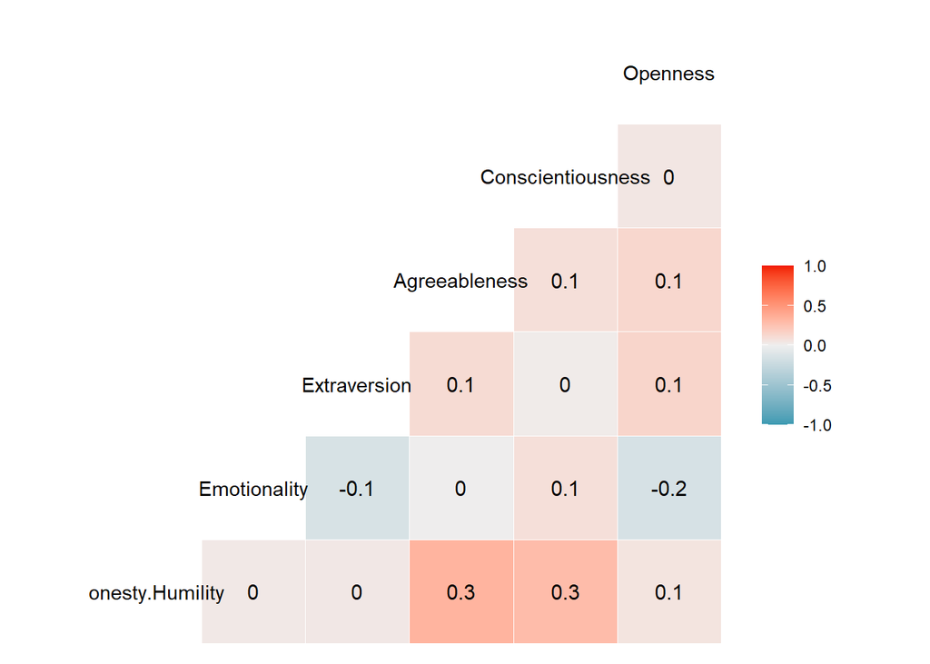

```r
library(GGally)
df2_numeric <- df2_clean %>%
  dplyr :: select(Honesty.Humility:Openness)
ggcorr(df2_numeric, label = TRUE)
```

A correlation matrix was generated to understand relationships between the personality traits (Honesty-Humility, Emotionality, Extraversion, Agreeableness, Conscientiousness, and Openness). The analysis revealed relatively weak correlations overall, ranging from -0.2 to 0.3, indicating that these personality traits are relatively independent from each other.

#Gender Distribution:

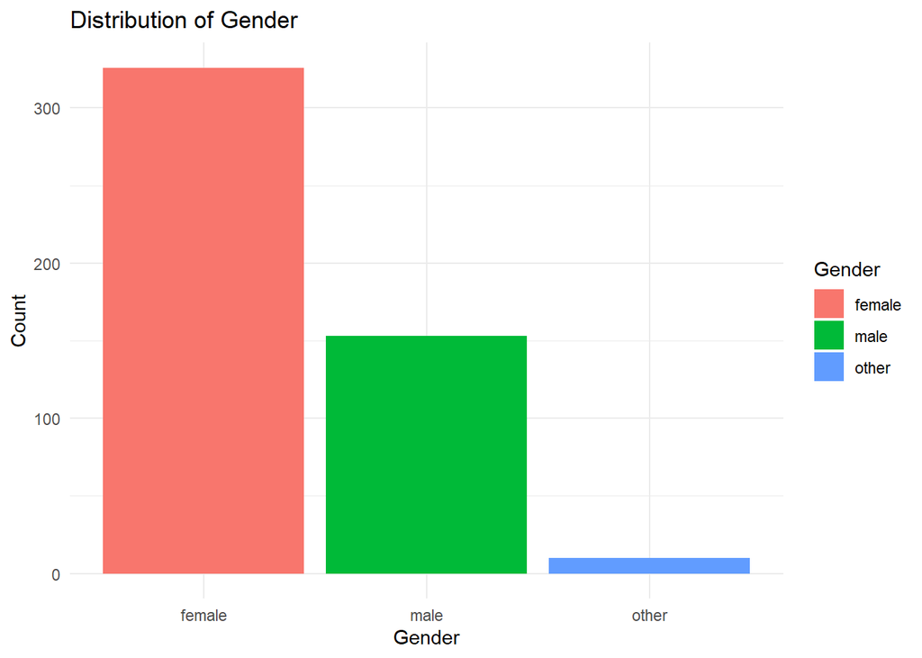

```r
 ggplot(df2_clean, aes(x = Gender, fill = Gender)) +
  geom_bar() +
  theme_minimal()+
   labs(title = "Distribution of Gender", x = "Gender", y = "Count")
```

#Train/Test Split

```r
set.seed(42)
train_index <- createDataPartition(df2_clean$Gender, p = 0.8, list = FALSE)
train <- df2_clean[train_index, ]
test  <- df2_clean[-train_index, ]

# Class distribution check
prop.table(table(train$Gender))
```

```
##
##     female       male      other
## 0.66581633 0.31377551 0.02040816
```

```r
prop.table(table(test$Gender))
```

```
##
##     female       male      other
## 0.67010309 0.30927835 0.02061856
```

The dataset is imbalanced, with “Female” being the dominant class, while the “Other” category has very few samples, making accurate prediction difficult. To ensure model stability and reduce noise during training, we will focus on binary classification by removing rows labeled “Other” and only considering “Female” vs “Male.” For evaluation, we will use a confusion matrix and ROC-AUC score, which is applicable for binary classification.

#Filter to Binary Classes Only (Female vs Male)

```r
# Filter for binary classification (remove "other")
df_binary <- df2_clean %>% filter(Gender %in% c("female", "male"))

# Re-split
set.seed(42)
train_index <- createDataPartition(df_binary$Gender, p = 0.8, list = FALSE)
train <- df_binary[train_index, ]
test  <- df_binary[-train_index, ]

# Drop unused factor level
train$Gender <- droplevels(train$Gender)
test$Gender <- droplevels(test$Gender)

# Check
table(train$Gender)
```

```
##
## female   male
##    261    123
```

#Model Development and Evaluation Three models were trained and evaluated:

#Logistic regression

```r
library(reshape2)
model_log <- glm(Gender ~ ., data = train, family = "binomial")

# Predict probabilities
pred_log_prob <- predict(model_log, test, type = "response")


pred_log_class <- ifelse(pred_log_prob > 0.5, "male", "female") %>% as.factor()

# Confusion Matrix
confusionMatrix(pred_log_class, test$Gender)
```

```
## Confusion Matrix and Statistics
##
##           Reference
## Prediction female male
##     female     61   15
##     male        4   15
##
##                Accuracy : 0.8
##                  95% CI : (0.7054, 0.8751)
##     No Information Rate : 0.6842
##     P-Value [Acc > NIR] : 0.00833
##
##                   Kappa : 0.4865
##
##  Mcnemar's Test P-Value : 0.02178
##
##             Sensitivity : 0.9385
##             Specificity : 0.5000
##          Pos Pred Value : 0.8026
##          Neg Pred Value : 0.7895
##              Prevalence : 0.6842
##          Detection Rate : 0.6421
##    Detection Prevalence : 0.8000
##       Balanced Accuracy : 0.7192
##
##        'Positive' Class : female
##
```

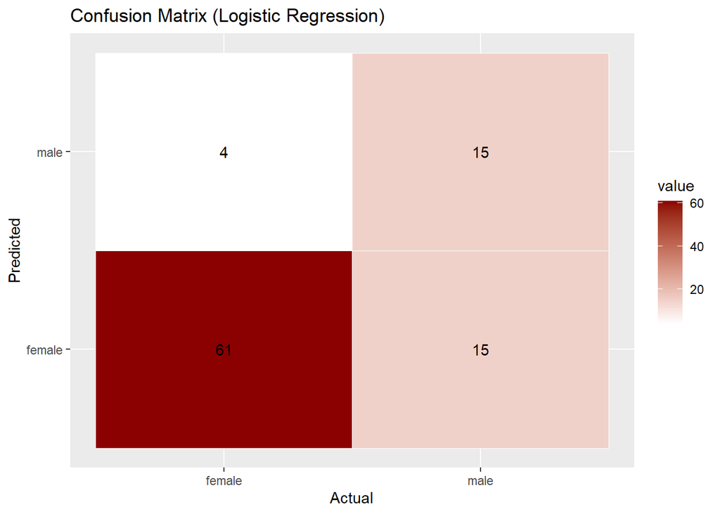

```r
cm <- table(Predicted = pred_log_class, Actual = test$Gender)
cm_melt <- melt(cm)

ggplot(cm_melt, aes(x = Actual, y = Predicted)) +
  geom_tile(aes(fill = value), color = "white") +
  geom_text(aes(label = value)) +
  scale_fill_gradient(low = "white", high = "darkred") +
  labs(title = "Confusion Matrix (Logistic Regression)")
```

We used binomial logistic regression with all features to classify “Female” vs “Male.” Model performance was assessed via confusion matrix and ROC curve, with AUC summarizing overall accuracy.

The logistic regression model correctly identified 61/65 females (93.8% sensitivity) and 15/30 males (50% specificity), with 4 females misclassified as males and 15 males misclassified as females, showing strong performance for female detection but weaker accuracy for males.

#ROC & AUC (Logistic)

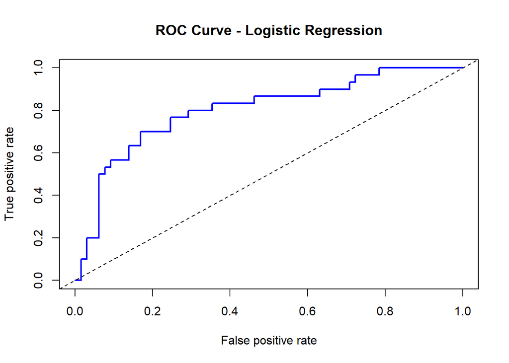

```r
test_binary <- test %>%
  mutate(Gender_binary = ifelse(Gender == "male", 1, 0))

pred_log_prob <- predict(model_log, test, type = "response")
pred_obj <- prediction(pred_log_prob, test_binary$Gender_binary)
perf <- performance(pred_obj, "tpr", "fpr")
plot(perf, col = "blue", lwd = 2, main = "ROC Curve - Logistic Regression")
abline(a = 0, b = 1, lty = 2)
```

```r
auc <- performance(pred_obj, "auc")@y.values[[1]]
print(paste("AUC =", round(auc, 3)))
```

```
## [1] "AUC = 0.803"
```

The model achieved an AUC of 0.803, indicating excellent discriminative ability (values >0.8 are considered excellent) and strong predictive power for gender classification based on personality traits, supporting the hypothesis that statistically detectable personality differences exist between genders.

#Random forest

```r
set.seed(123)
model_rf <- randomForest(Gender ~ ., data = train, importance = TRUE)

# Predict
pred_rf <- predict(model_rf, test)

# Confusion Matrix
confusionMatrix(pred_rf, test$Gender)
```

```
## Confusion Matrix and Statistics
##
##           Reference
## Prediction female male
##     female     54   13
##     male       11   17
##
##                Accuracy : 0.7474
##                  95% CI : (0.6478, 0.8309)
##     No Information Rate : 0.6842
##     P-Value [Acc > NIR] : 0.1109
##
##                   Kappa : 0.4047
##
##  Mcnemar's Test P-Value : 0.8383
##
##             Sensitivity : 0.8308
##             Specificity : 0.5667
##          Pos Pred Value : 0.8060
##          Neg Pred Value : 0.6071
##              Prevalence : 0.6842
##          Detection Rate : 0.5684
##    Detection Prevalence : 0.7053
##       Balanced Accuracy : 0.6987
##
##        'Positive' Class : female
##
```

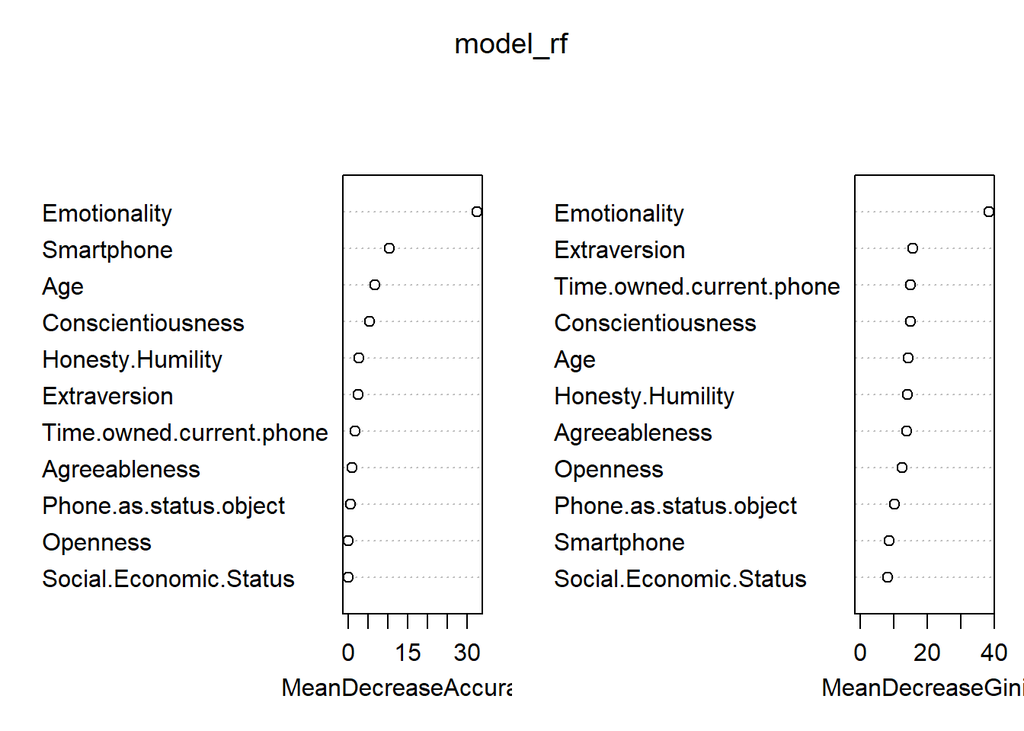

```r
varImpPlot(model_rf)
```

A Random Forest classifier was implemented to enhance prediction accuracy and determine feature importance. To calculate AUC, probability scores rather than class labels were generated by setting type=“prob”, allowing assessment of the model’s confidence in class predictions. AUC measures classification performance across all thresholds, providing threshold-independent evaluation particularly valuable for imbalanced datasets.

The confusion matrix shows the Random Forest model correctly classified 54/65 females and 17/30 males, while misclassifying 11 females as males and 13 males as females. Overall accuracy reached 74.7% (71/95 correct), with 83.1% sensitivity for females but only 56.7% specificity for males, revealing the same gender-based classification disparity observed in the logistic regression model.

The Random Forest model revealed Emotionality as the strongest gender predictor across both importance metrics. Using MDA, the top predictors were Emotionality, Smartphone, Age, and Conscientiousness. MDG showed a slightly different order: Emotionality, Extraversion, Time Owned Current Phone, and Conscientiousness. The consistent high ranking of Emotionality and Conscientiousness across both metrics confirms their robust association with gender classification.

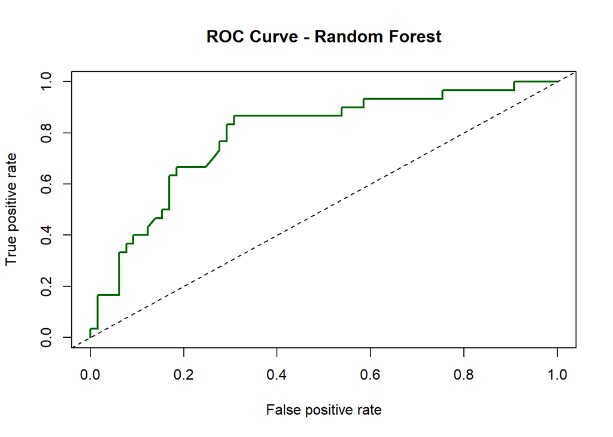

```r
pred_rf_prob <- predict(model_rf, test, type = "prob")[, "male"]

# Convert test Gender to binary (male = 1, female = 0)
test_binary <- ifelse(test$Gender == "male", 1, 0)

# Evaluate AUC
pred_rf_obj <- prediction(pred_rf_prob, test_binary)
perf_rf <- performance(pred_rf_obj, "tpr", "fpr")
plot(perf_rf, col = "darkgreen", lwd = 2, main = "ROC Curve - Random Forest")
abline(0, 1, lty = 2)
```

```r
# AUC
auc_rf <- performance(pred_rf_obj, "auc")@y.values[[1]]
print(paste("AUC (Random Forest) =", round(auc_rf, 3)))
```

```
## [1] "AUC (Random Forest) = 0.791"
```

The Random Forest model achieved an AUC of 0.791, showing good discriminative ability though marginally lower than logistic regression’s 0.803, suggesting both captured similar personality-gender patterns. Despite slightly lower overall accuracy, Random Forest demonstrated more balanced gender classification, correctly identifying more males (17 vs. 15) while sacrificing some female classification accuracy.

#Naive bayes

```r
library(e1071)
model_nb <- naiveBayes(Gender ~ ., data = train)

# Predict class and probability
pred_nb_class <- predict(model_nb, test)
pred_nb_prob <- predict(model_nb, test, type = "raw")[, "male"]

# Confusion Matrix
confusionMatrix(pred_nb_class, test$Gender)
```

```
## Confusion Matrix and Statistics
##
##           Reference
## Prediction female male
##     female     57   14
##     male        8   16
##
##                Accuracy : 0.7684
##                  95% CI : (0.6706, 0.8488)
##     No Information Rate : 0.6842
##     P-Value [Acc > NIR] : 0.0461
##
##                   Kappa : 0.4336
##
##  Mcnemar's Test P-Value : 0.2864
##
##             Sensitivity : 0.8769
##             Specificity : 0.5333
##          Pos Pred Value : 0.8028
##          Neg Pred Value : 0.6667
##              Prevalence : 0.6842
##          Detection Rate : 0.6000
##    Detection Prevalence : 0.7474
##       Balanced Accuracy : 0.7051
##
##        'Positive' Class : female
##
```

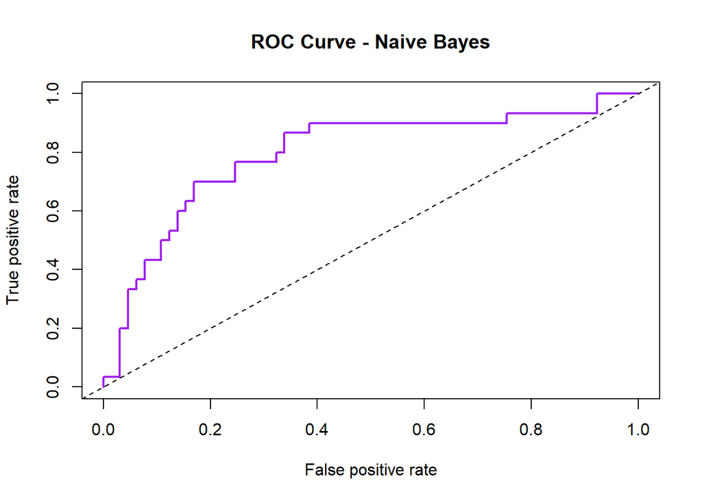

```r
pred_nb_obj <- prediction(pred_nb_prob, ifelse(test$Gender == "male", 1, 0))
perf_nb <- performance(pred_nb_obj, "tpr", "fpr")
plot(perf_nb, col = "purple", lwd = 2, main = "ROC Curve - Naive Bayes")
abline(0, 1, lty = 2)
```

```r
auc_nb <- performance(pred_nb_obj, "auc")@y.values[[1]]
print(paste("AUC (Naive Bayes) =", round(auc_nb, 3)))
```

```
## [1] "AUC (Naive Bayes) = 0.795"
```

We also implemented a Bayesian classification approach using Naive Bayes, a probabilistic model assuming feature independence. Performance was evaluated through a confusion matrix for accuracy, while a ROC curve was plotted to analyze behavior across thresholds. AUC was calculated to enable comparison with other models.

The Naive Bayes model correctly classified 57 females and 16 males, with 8 false positives and 14 false negatives, achieving 76.8% accuracy—between logistic regression (80.0%) and Random Forest (74.7%). It showed 87.7% sensitivity for females and 53.3% specificity for males, reinforcing the trend that female profiles are more distinct and easier to classify.

The Naive Bayes model achieved an AUC of 0.795, comparable to logistic regression (0.803) and Random Forest (0.791), indicating strong discriminative ability. This consistency across models suggests a robust link between personality traits and gender. Notably, Naive Bayes performed well despite assuming feature independence—likely violated among traits—showing that even simple trait-gender relationships hold strong predictive value.

#Results and Model Comparison

Metric Logistic Regression Random Forest Naive Bayes (Bayesian) Accuracy 0.800 0.747 0.768 Kappa 0.486 0.405 0.434 Sensitivity 0.939 0.831 0.877 Specificity 0.500 0.567 0.533 AUC 0.803 0.791 0.795

While all models performed well, logistic regression was selected as the final model due to its: • Highest AUC (0.803) & Accuracy(0.800) • High sensitivity and reasonable specificity • Interpretability — allowing us to understand which traits influenced classification most

#Why AUC? AUC was chosen over raw accuracy due to the dataset’s imbalance (~67% female) and its ability to evaluate model performance across all thresholds. It captures both sensitivity and specificity, which is crucial for balanced gender classification.

#Limitations and Considerations • The binary approach excludes the “Other” gender category, reducing inclusivity. • HEXACO traits are self-reported and subjective, potentially introducing noise. • Additional features or interaction terms could potentially improve model performance • More sophisticated ensemble methods or deep learning approaches might yield even better results